# Test8

## General Introduction

This test is designed to reproduce the figure 3b and 4b from the Rosenbaum 2017 paper:

Rosenbaum, Robert, et al. "The spatial structure of correlated neuronal variability." Nature neuroscience 20.1 (2017): 107-114.

These figures illustrate the covariance between different types of input current depends on distance. In particular, it shows EI balance breaks as the recurrent connections extend further than feedforward connections.

This test therefore relies on spatially structured networks and the measurement of different types of input current. The features tested are : Distance Connectivity, SpatialPoissonStimulus, EIFNeuron and CurrentContribution recording.

Warning: This test is very heavy. The simulations can take hours to run, the generated files are large (~1GB) and can also take some time to load and process.

This Live Script runs with Matlab

## Figures

%% Import Data

base_path = 'C:/Users/ekelmansp/Documents';

project_name1 = 'Test8A';%For the figure 3B. project_name is an identifier of the folder(s) containing the simulation data. The date suffix does not need to be included

project_name2 = 'Test8B';%For the figure 4B. Idem

%% Import data Fig3B

folderlist=dir([base_path filesep project_name1 '_20*']);

folder_name=folderlist(end).name;

cd([base_path filesep folder_name])

filename = [project_name1 '_CurrentContribution.dat'];

delimiter = '\t';

startRow = 11;

formatEl='%f';

formatSpec=formatEl;%the first column is time;

for i=1:500

formatSpec=[formatSpec formatEl formatEl formatEl];%Each of the 500 recoreded neurons has 3 sources of inputs: recurrent E and I and feedforward

end

formatSpec=[formatSpec '%[^\n\r]'];

fileID = fopen(filename,'r');

dataArray = textscan(fileID, formatSpec, 'Delimiter', delimiter, 'EmptyValue' ,NaN,'HeaderLines' ,startRow-1, 'ReturnOnError', false, 'EndOfLine', '\r\n');

fclose(fileID);

Test8A = [dataArray{1:end-1}];

clearvars filename fileID dataArray ans;

%% Import data Fig4B

folderlist=dir([base_path filesep project_name2 '_20*']);

folder_name=folderlist(end).name;

cd([base_path filesep folder_name])

filename = [project_name2 '_CurrentContribution.dat'];

fileID = fopen(filename,'r');

dataArray = textscan(fileID, formatSpec, 'Delimiter', delimiter, 'EmptyValue' ,NaN,'HeaderLines' ,startRow-1, 'ReturnOnError', false, 'EndOfLine', '\r\n');

fclose(fileID);

Test8B = [dataArray{1:end-1}];

clearvars filename delimiter startRow formatSpec fileID dataArray ans;

%% Analysis 3B and 4B (adapted from Rosenbaum et al., 2017 available Supplementary software)

Ntot=4e4;

Nrec=500;

Nx=sqrt(Ntot);

Index=0:Ntot/Nrec:Ntot-1;

Irecord=[1/Nx*floor(Index/Nx);1/Nx*mod(Index,Nx)];%(xy coordinates of each neuron recorded)

dt=0.5;

% Function to compute distances

distfun=@(x1,y1,x2,y2)(sqrt(min(abs(x1-x2),1-abs(x1-x2)).^2+min(abs(y1-y2),1-abs(y1-y2)).^2));

% distance bins

binsize=0.025;

bd=[1/Nx-1e-9 binsize:binsize:.708];

% Time constant of filter

tauKc=15;

% Low-pass filter

Kc=exp(-abs(-5*tauKc:dt:5*tauKc)/tauKc);

Kc=Kc/sum(Kc);

for it=[0 1]%Respectively the 3B and 4B figure; both share the same pipeline

if it==0

Irec=Test8A(2:end-1,2:501)'+Test8A(2:end-1,502:1001)';

Iffd=Test8A(2:end-1,1002:1501)';

Tburn=round(2/(Test8A(2,1)-Test8A(1,1)));

else

Irec=Test8B(2:end-1,2:501)'+Test8B(2:end-1,502:1001)';

Iffd=Test8B(2:end-1,1002:1501)';

Tburn=round(2/(Test8B(2,1)-Test8B(1,1)));

end

% Two-dim filter

Kcc=zeros(size(Iffd,1)*2+1,numel(Kc));

Kcc(size(Iffd,1)+1,:)=Kc;

% Low-pass filter currents

Irec0=conv2(Irec,Kcc,'same');

Iffd0=conv2(Iffd,Kcc,'same');

clear Kcc;

% Get rid of beginning and end,

% which are corrupted by initial transient

% and by filtering

Irec0=Irec0(:,round(Tburn):end);

Iffd0=Iffd0(:,round(Tburn):end);

% locations of recorded neurons

xlocs=Irecord(1,:);

ylocs=Irecord(2,:);

% Distances between neurons

[x1,x2]=meshgrid(xlocs,xlocs);

[y1,y2]=meshgrid(ylocs,ylocs);

distances=distfun(x1(:),y1(:),x2(:),y2(:));

% Compute covariance matrix between

% all ffwd and all rec inputs

AllCovs=cov([Iffd0; Irec0]');

% Get ffwd-rec covariances

FRCovs=AllCovs(1:Nrec,(Nrec+1):end);

FRCovs=FRCovs(:);

% Get ffwd-ffwd covs

FFCovs=AllCovs(1:Nrec,1:Nrec);

FFCovs=FFCovs(:);

% Get rec-rec covs

RRCovs=AllCovs(Nrec+1:end,Nrec+1:end);

RRCovs=RRCovs(:);

TotalCovs=FFCovs+RRCovs+2*FRCovs;

% Compute mean and stderr of all covariances

% over each distance bin

[~,I]=histc(distances,bd);

mFRCovs=zeros(numel(bd)-1,1);

errFRCovs=zeros(numel(bd)-1,1);

mFFCovs=zeros(numel(bd)-1,1);

errFFCovs=zeros(numel(bd)-1,1);

mRRCovs=zeros(numel(bd)-1,1);

errRRCovs=zeros(numel(bd)-1,1);

mTotalCovs=zeros(numel(bd)-1,1);

errTotalCovs=zeros(numel(bd)-1,1);

for j=1:numel(bd)-1

mFRCovs(j)=mean(FRCovs(I==j));

errFRCovs(j)=std(FRCovs(I==j))./sqrt(nnz((I==j)));

mFFCovs(j)=mean(FFCovs(I==j));

errFFCovs(j)=std(FFCovs(I==j))./sqrt(nnz((I==j)));

mRRCovs(j)=mean(RRCovs(I==j));

errRRCovs(j)=std(RRCovs(I==j))./sqrt(nnz((I==j)));

mTotalCovs(j)=mean(TotalCovs(I==j));

errTotalCovs(j)=std(TotalCovs(I==j))./sqrt(nnz((I==j)));

end

bd=bd(1:end-1);

figure

plot(bd,mFRCovs/mFFCovs(1),'m','LineWidth',2)

hold on

plot(bd,mFFCovs./mFFCovs(1),'b','LineWidth',2)

plot(bd,mRRCovs./mFFCovs(1),'r','LineWidth',2)

plot(bd,mTotalCovs./mFFCovs(1),'k','LineWidth',2)

xlabel('distance (a.u.)')

ylabel('Current covariance (normalized)')

legend('ffd-rec','ffd-ffd','rec-rec','Tot')

set(gca,'FontSize',16)

if it==0

title('3B')

else

title('4B')

end

axis tight

end

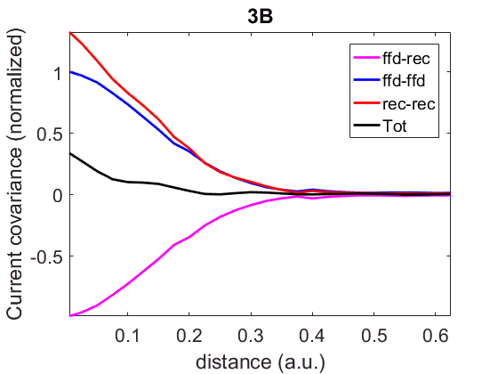

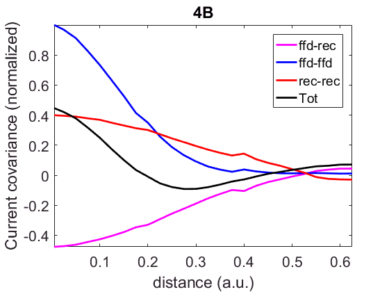

These figures must be compared to the corresponding figures in the Rosenbaum 2017 paper. Figure 3B shows that for narrow recurrent connections, feedforward and recurrent inputs tightly balance out. Figure 4B shows that for longer recurrent connections, however, the cancellation is less tight and varies with distance.